# Homework3

This shows the graph of y axis belonging training data. In this case, cumulative sum is considered.

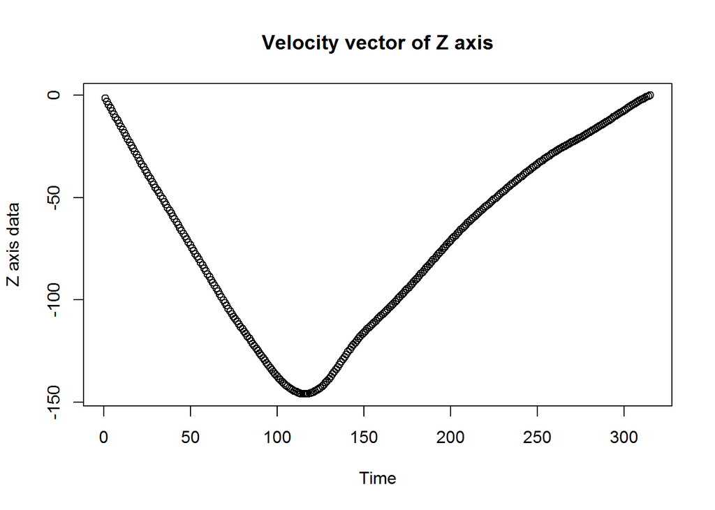

Figure 32: Z axis for Class 6 with cumulative sum(Velocity vector of Z axis)

This shows the graph of z axis belonging training data. In this case, cumulative sum is considered.

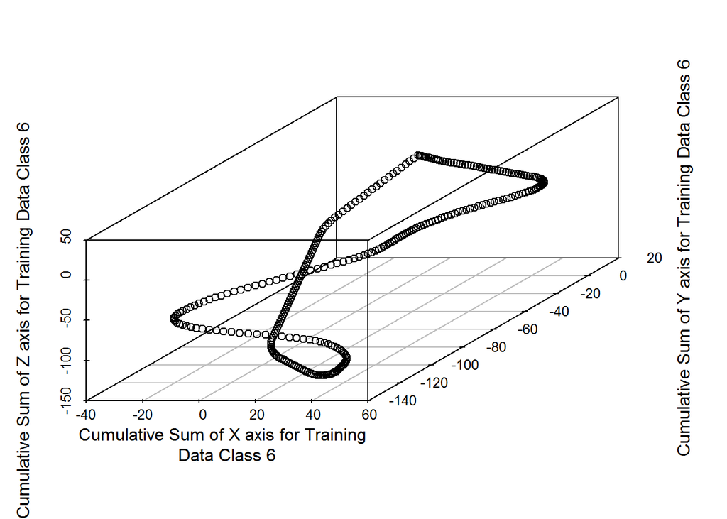

Figure 33: XYZ axis for Class 6 with cumulative sum(Velocity vector of XYZ axis)

This shows the graph of xyz axis belonging training data. In this case, cumulative sum is considered. This is the visualization of one instance of Class 6.

**For the 7. Class**

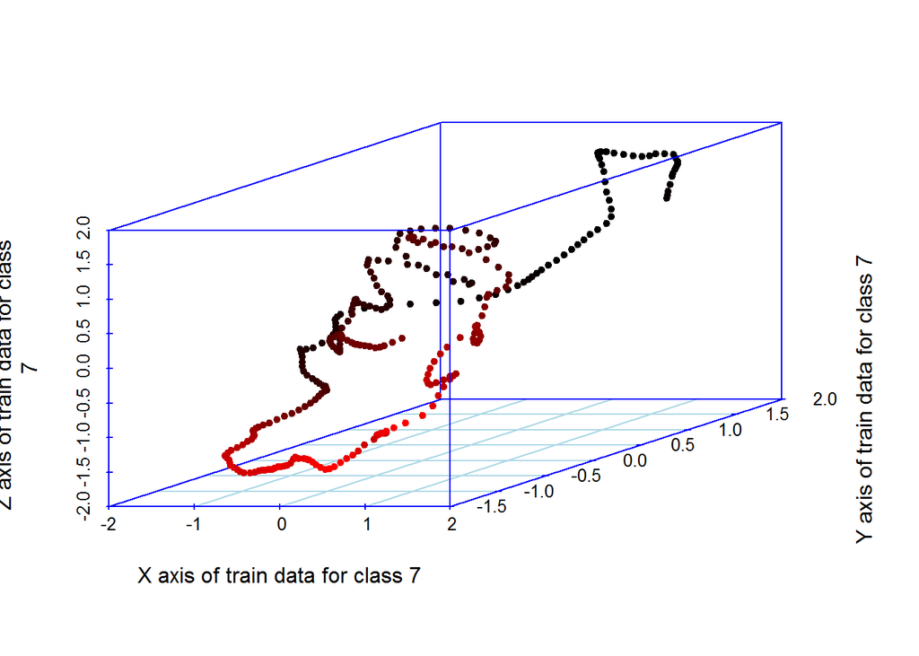

Figure 34: XYZ axis for class 7 without cumulative sum

If I want to see the combined version of x,y and z axis, this kind of plot can be observed.In this case, vectors are not cumulative.

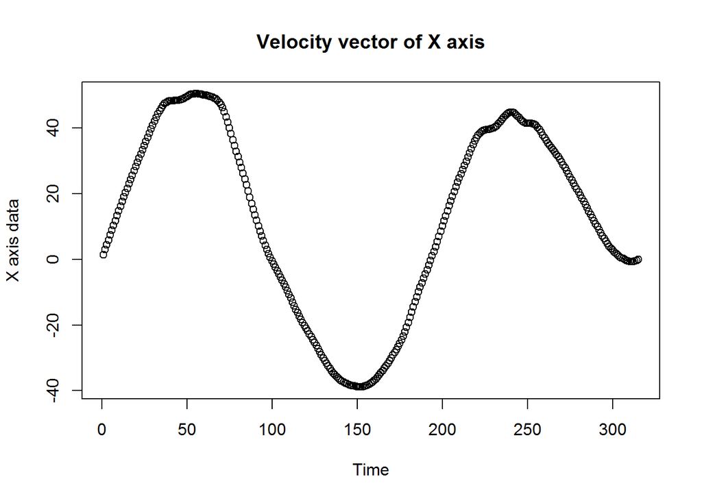

Figure 35: X axis for Class 7 with cumulative sum(Velocity vector of X axis)

This shows the graph of x axis belonging training data. In this case, cumulative sum is considered.

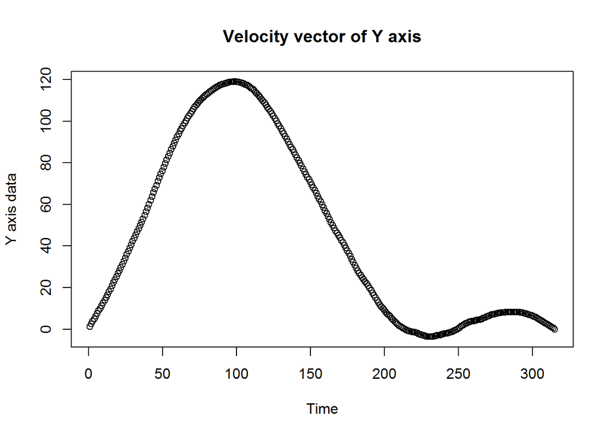

Figure 36: Y axis for Class 7 with cumulative sum(Velocity vector of Y axis)

This shows the graph of y axis belonging training data. In this case, cumulative sum is considered.

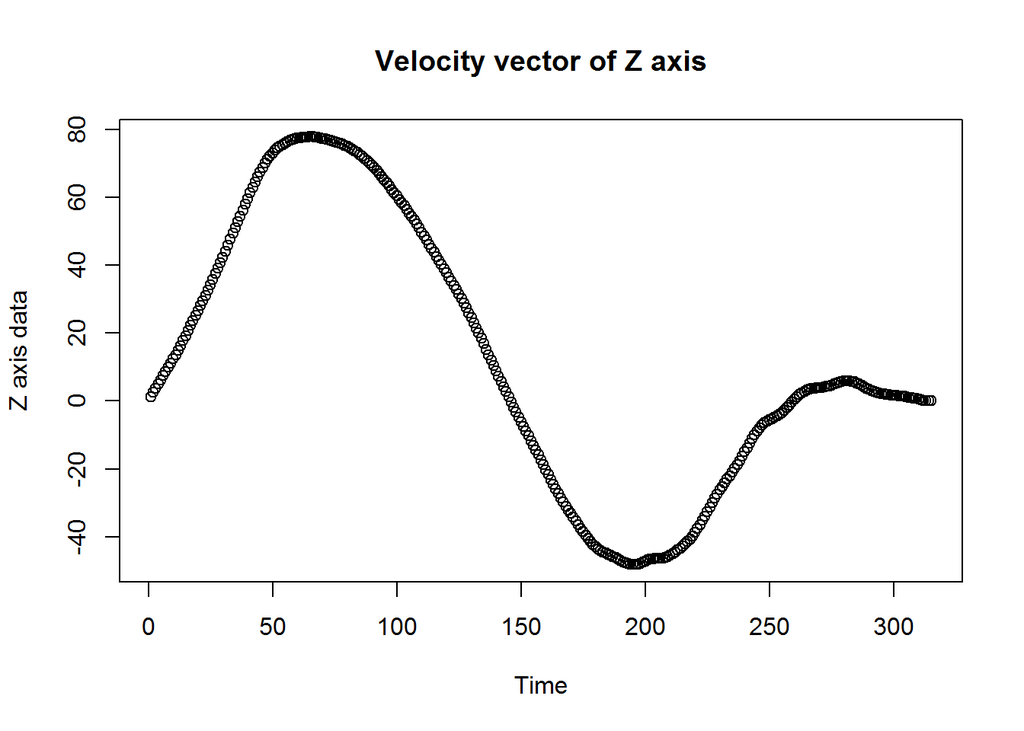

Figure 37: Z axis for Class 7 with cumulative sum(Velocity vector of Z axis)

This shows the graph of z axis belonging training data. In this case, cumulative sum is considered.

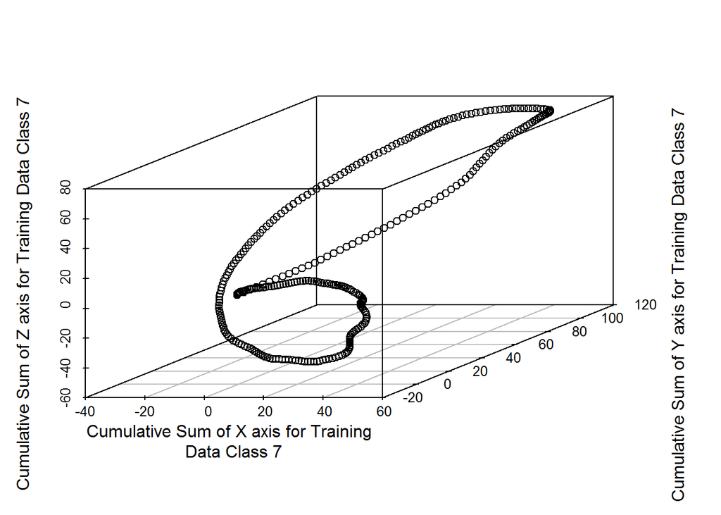

Figure 38: XYZ axis for Class 7 with cumulative sum(Velocity vector of XYZ axis)

This shows the graph of xyz axis belonging training data. In this case, cumulative sum is considered. This is the visualization of one instance of Class 7.

**For the 8. Class**

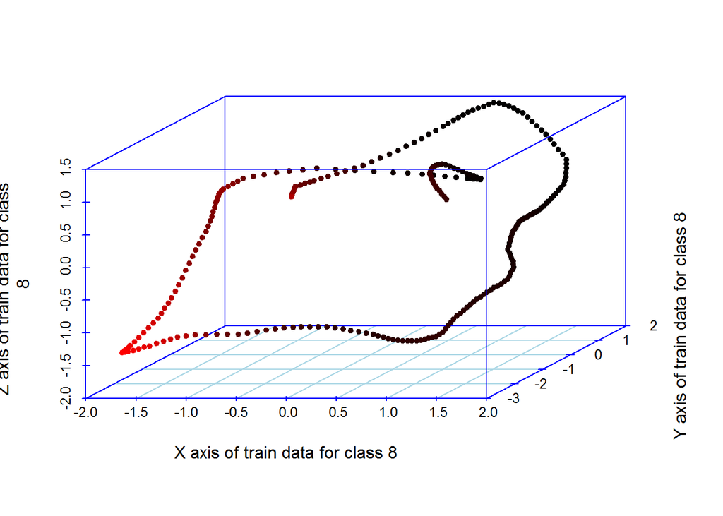

If I want to see the combined version of x,y and z axis, this kind of plot can be observed.In this case, vectors are not cumulative.

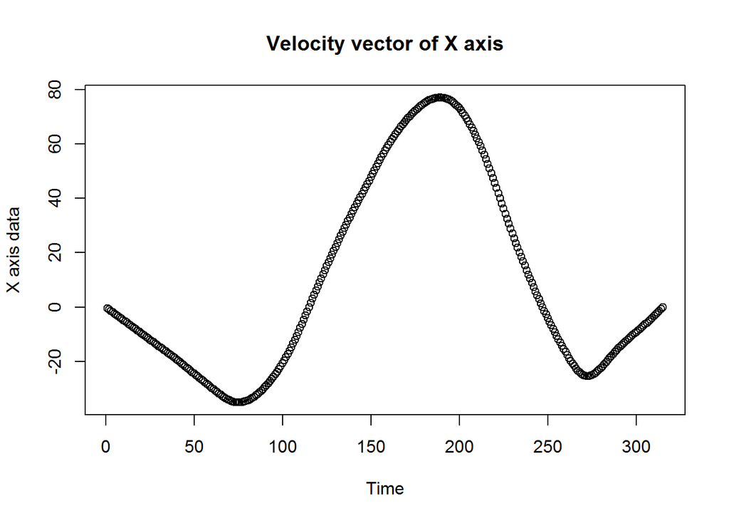

Figure 40: X axis for Class 8 with cumulative sum(Velocity vector of X axis)

This shows the graph of x axis belonging training data. In this case, cumulative sum is considered.

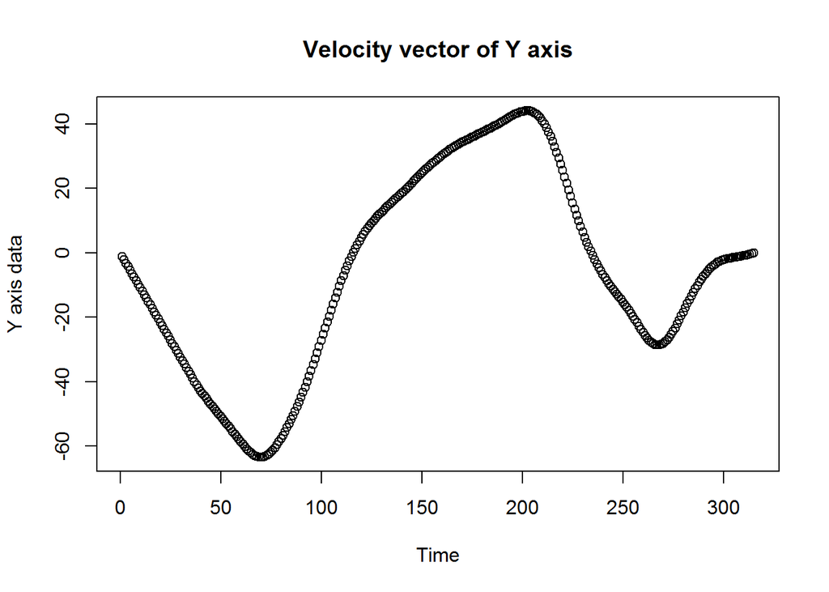

Figure 41: Y axis for Class 8 with cumulative sum(Velocity vector of Y axis)

This shows the graph of y axis belonging training data. In this case, cumulative sum is considered.

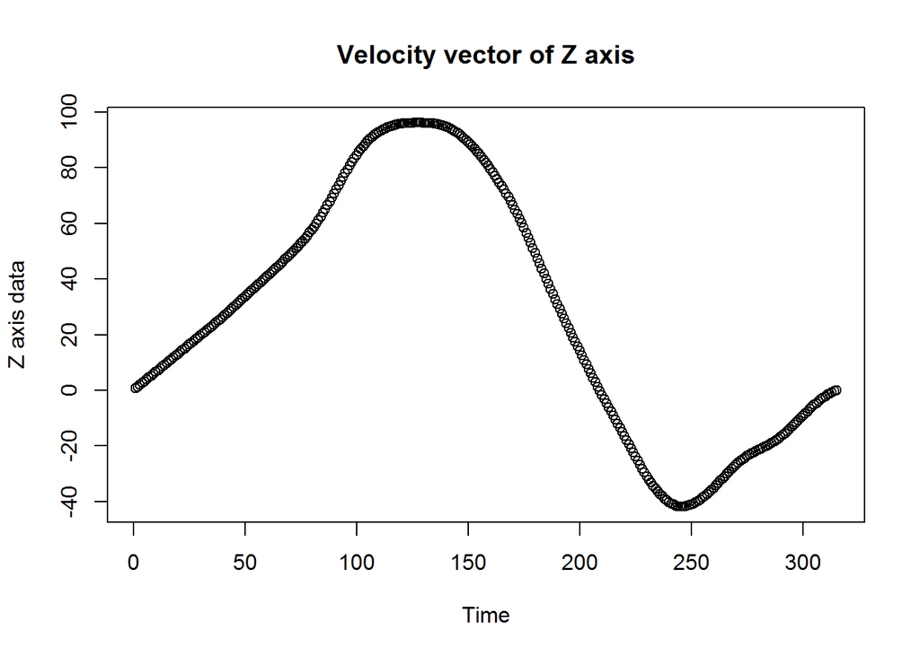

Figure 42: Z axis for Class 8 with cumulative sum(Velocity vector of Z axis)

This shows the graph of z axis belonging training data. In this case, cumulative sum is considered.

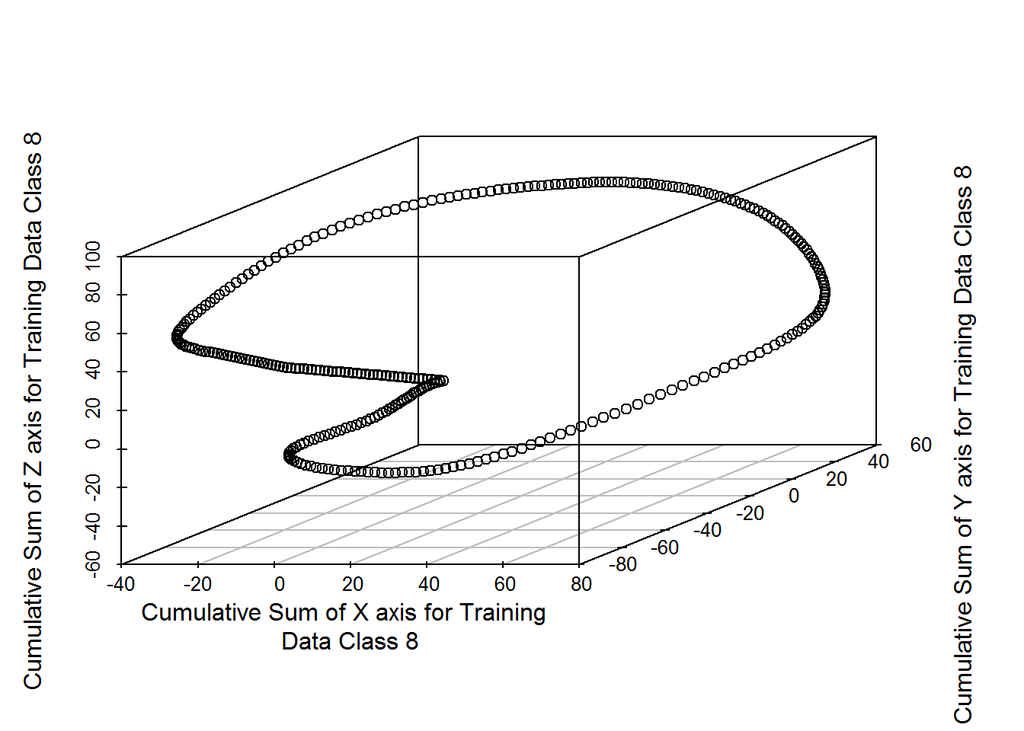

Figure 43: XYZ axis for Class 8 with cumulative sum(Velocity vector of XYZ axis)

This shows the graph of xyz axis belonging training data. In this case, cumulative sum is considered. This is the visualization of one instance of Class 8.

When I look at the cumulative sum plots for XYZ axis of each class, ı can see some similarities between the graph and the visual representation of classes given on paper. For instance, first class’ graph is a bit more similar to 7. representation on paper. Second class’s graph is similar to both 1. and 2. visual representation on paper but i think more similar to 1. Moreover, 6. class’ graph is more similar to 6. visual representation. Actually, all is similar to each other someway. Surely, we should observe more instances’ situation in order to decide exact visual representation of each class done.

**Part b**

**For Test data**

**Class 1**

```
##                    X             Y             Z
##   [1,]  4.250000e-07  1.649994e-08  3.005000e-07
##   [2,] -2.880001e-07 -1.062000e-06  4.189995e-08
##   [3,] -2.333000e-07  1.029200e-06 -5.599999e-07
##   [4,] -5.287000e-07 -1.646000e-07  3.179998e-07
##   [5,]  7.200002e-08 -1.323200e-06  1.980000e-07
##   [6,]  1.252000e-07  7.000317e-09  1.195400e-06
##   [7,]  8.152000e-07  2.328999e-07  4.731201e-07
##   [8,] -1.829001e-07  1.992000e-07 -1.664500e-06
##   [9,]  3.730000e-07 -4.705802e-07 -3.348000e-07
##  [10,]  5.847001e-07 -3.389499e-07 -1.943000e-07
##  [11,]  3.270000e-07  3.085301e-07 -1.306000e-06
##  [12,]  3.429000e-07 -1.510001e-07  3.330000e-07
##  [13,]  2.930001e-07 -1.344000e-07  5.730000e-07
##  [14,]  3.389101e-07  1.591000e-06 -5.553000e-07
```

[output cut: 423 more lines]

Figure 44: Test data of Class 1

This table represents test data of class 1. Each column represents X,Y,Z axis of the data,respectively.

```
##            1         2         3         4         5         6         7
## 1    0.00000  32.55739  64.33586  95.39932 125.67167 154.89155 182.87589
## 2   32.55739   0.00000  32.19272  63.65755  94.33405 123.96438 152.37437
## 3   64.33586  32.19272   0.00000  31.79936  62.81695  92.81584 121.62220
## 4   95.39932  63.65755  31.79936   0.00000  31.29782  61.60388  90.76897
## 5  125.67167  94.33405  62.81695  31.29782   0.00000  30.57024  60.03762
## 6  154.89155 123.96438  92.81584  61.60388  30.57024   0.00000  29.72775
## 7  182.87589 152.37437 121.62220  90.76897  60.03762  29.72775   0.00000
## 8  209.81451 179.75839 149.43022 118.97602  88.60660  58.59186  29.11277
## 9  235.79976 206.21455 176.34186 146.32640 116.37044  86.71885  57.52297
## 10 261.08074 231.99291 202.60617 173.06483 143.56414 114.32686  85.47700
## 11 285.79879 257.23537 228.36438 199.32986 170.32051 141.53873 113.08343
## 12 310.11771 282.10289 253.77318 225.27202 196.78154 168.48478 140.45757
## 13 334.18839 306.74086 278.97113 251.02152 223.06722 195.27277 167.69289
## 14 358.12639 331.25820 304.05951 276.67084 249.26019 221.97444 194.84912
```

[output cut: 48 more lines]

Figure 45: Euclidean Distance of Class 1 data

You can view the euclidean distances as can be seen on the above graph.

```
##                1            2            3            4            5
## 2   3.000509e+00
## 3   6.001018e+00 3.000509e+00
## 4   9.004930e+00 6.004421e+00 3.003912e+00
## 5   1.201976e+01 9.019247e+00 6.018738e+00 3.014826e+00
## 6   1.506470e+01 1.206419e+01 9.063680e+00 6.059768e+00 3.044942e+00
## 7   1.815135e+01 1.515084e+01 1.215033e+01 9.146415e+00 6.131590e+00
## 8   2.125928e+01 1.825877e+01 1.525826e+01 1.225435e+01 9.239523e+00
## 9   2.438217e+01 2.138167e+01 1.838116e+01 1.537724e+01 1.236242e+01
## 10  2.750507e+01 2.450456e+01 2.150405e+01 1.850014e+01 1.548531e+01
## 11  3.062797e+01 2.762746e+01 2.462695e+01 2.162304e+01 1.860821e+01
## 12  3.375086e+01 3.075035e+01 2.774984e+01 2.474593e+01 2.173111e+01
## 13  3.687376e+01 3.387325e+01 3.087274e+01 2.786883e+01 2.485400e+01
## 14  3.999665e+01 3.699614e+01 3.399564e+01 3.099172e+01 2.797690e+01
## 15  4.311955e+01 4.011904e+01 3.711853e+01 3.411462e+01 3.109979e+01
## 16  4.624244e+01 4.324194e+01 4.024143e+01 3.723751e+01 3.422269e+01
## 17  4.936534e+01 4.636483e+01 4.336432e+01 4.036041e+01 3.734558e+01
## 18  5.248824e+01 4.948773e+01 4.648722e+01 4.348331e+01 4.046848e+01
## 19  5.561113e+01 5.261062e+01 4.961011e+01 4.660620e+01 4.359138e+01
## 20  5.873403e+01 5.573352e+01 5.273301e+01 4.972910e+01 4.671427e+01
## 21  6.185692e+01 5.885641e+01 5.585590e+01 5.285199e+01 4.983717e+01
## 22  6.497982e+01 6.197931e+01 5.897880e+01 5.597489e+01 5.296006e+01
## 23  6.810271e+01 6.510220e+01 6.210170e+01 5.909778e+01 5.608296e+01
## 24  7.122561e+01 6.822510e+01 6.522459e+01 6.222068e+01 5.920585e+01
## 25  7.434850e+01 7.134800e+01 6.834749e+01 6.534357e+01 6.232875e+01
## 26  7.747140e+01 7.447089e+01 7.147038e+01 6.846647e+01 6.545165e+01
## 27  8.059430e+01 7.759379e+01 7.459328e+01 7.158937e+01 6.857454e+01
## 28  8.371719e+01 8.071668e+01 7.771617e+01 7.471226e+01 7.169744e+01
## 29  8.684009e+01 8.383958e+01 8.083907e+01 7.783516e+01 7.482033e+01
## 30  8.996298e+01 8.696247e+01 8.396197e+01 8.095805e+01 7.794323e+01
## 31  9.308089e+01 9.008038e+01 8.707987e+01 8.407596e+01 8.106113e+01
## 32  9.618222e+01 9.318171e+01 9.018120e+01 8.717729e+01 8.416246e+01
## 33  9.926066e+01 9.626015e+01 9.325964e+01 9.025573e+01 8.724090e+01
## 34  1.023122e+02 9.931171e+01 9.631120e+01 9.330729e+01 9.029246e+01
## 35  1.053587e+02 1.023582e+02 9.935772e+01 9.635381e+01 9.333899e+01
## 36  1.084028e+02 1.054023e+02 1.024018e+02 9.939784e+01 9.638302e+01
## 37  1.114468e+02 1.084463e+02 1.054458e+02 1.024419e+02 9.942705e+01
## 38  1.144908e+02 1.114903e+02 1.084898e+02 1.054859e+02 1.024711e+02
## 39  1.175349e+02 1.145344e+02 1.115338e+02 1.085299e+02 1.055151e+02
## 40  1.205609e+02 1.175603e+02 1.145598e+02 1.115559e+02 1.085411e+02
```

[output cut: 19853 more lines]

```
## 302
## 303
## 304
## 305
## 306
## 307
## 308
## 309
## 310
## 311
## 312 6.847268e-01
## 313 1.369454e+00 6.847268e-01
## 314 2.054180e+00 1.369454e+00 6.847268e-01
## 315 2.738907e+00 2.054180e+00 1.369454e+00 6.847268e-01
## 316 3.423634e+00 2.738907e+00 2.054180e+00 1.369454e+00 6.847268e-01
```

Figure 46: Manhattan Distance of Class 1 data

You can view the manhattan distances as can be seen on the above graph.

**Class 2**

```
##                    X             Y             Z
##   [1,] -6.929996e-08  1.261996e-08  5.713000e-07
##   [2,]  4.345000e-07 -4.589400e-07 -9.576839e-07
##   [3,]  4.360000e-07  1.670002e-07  6.065000e-07
##   [4,]  1.132000e-07 -1.278000e-07  5.106000e-08
##   [5,] -3.395000e-07 -3.060007e-08  2.179099e-07
##   [6,] -8.023000e-07 -7.830000e-07  1.780000e-07
##   [7,] -4.783800e-07  1.839000e-07 -2.657000e-07
##   [8,] -1.676000e-07  4.540001e-07  2.858000e-07
##   [9,]  4.261000e-07  9.900020e-09  3.730000e-07
##  [10,]  2.436500e-07 -1.877000e-07  9.474100e-07
##  [11,]  7.428003e-08  2.939000e-07 -4.360001e-08
##  [12,] -6.210000e-07  2.164299e-07  2.029996e-08
##  [13,] -5.160000e-08 -1.214000e-06  1.610000e-07
##  [14,] -6.628000e-07  1.721002e-07 -9.107000e-07
```

[output cut: 438 more lines]

Figure 47: Test data of Class 2

This table represents test data of class 2. Each column represents X,Y,Z axis of the data,respectively.

```
##            1         2         3         4         5         6         7
## 1    0.00000  35.23217  70.98735 107.25047 144.01539 181.14110 218.51137
## 2   35.23217   0.00000  36.06466  72.60332 109.67448 147.14064 184.88299
## 3   70.98735  36.06466   0.00000  36.80832  74.11999 111.86931 149.93388
## 4  107.25047  72.60332  36.80832   0.00000  37.57440  75.56214 113.91120
## 5  144.01539 109.67448  74.11999  37.57440   0.00000  38.25400  76.85438
## 6  181.14110 147.14064 111.86931  75.56214  38.25400   0.00000  38.87577
## 7  218.51137 184.88299 149.93388 113.91120  76.85438  38.87577   0.00000
## 8  255.99664 222.76857 188.17609 152.47904 115.72552  78.01936  39.43671
## 9  293.51437 260.71028 226.50266 191.16430 154.75449 117.37170  79.08464
## 10 331.07942 298.71647 264.91380 229.95658 193.91593 156.88495 118.92712
## 11 368.72216 336.81149 303.42675 268.86459 233.20782 196.54334 158.92966
## 12 406.44730 374.99603 342.03763 307.87945 272.61561 236.32627 199.06533
## 13 444.24647 413.25916 380.73275 346.98457 312.11978 276.21151 239.30951
## 14 482.10393 451.58355 419.49308 386.15929 351.69804 316.17544 279.63747
```

[output cut: 48 more lines]

Figure 48: Euclidean Distance of Class 2 data

You can view the euclidean distances as can be seen on the above graph.

**Class 3**

```
##                    X             Y             Z
##   [1,] -7.463001e-07  2.773001e-07 -1.589999e-07
##   [2,]  6.007002e-07 -1.461100e-06  5.480000e-07
##   [3,]  3.299987e-08 -9.490000e-07  9.495698e-07
##   [4,] -4.550001e-07 -2.170000e-07  5.720002e-08
##   [5,]  1.698000e-06 -7.679998e-07  3.341000e-06
##   [6,]  1.200002e-07 -3.923001e-07  1.244000e-06
##   [7,]  7.979999e-07  4.500001e-07  1.697000e-06
##   [8,] -2.663000e-06  1.849000e-06 -9.522999e-07
##   [9,] -5.610000e-07 -1.421000e-07 -5.990001e-07
##  [10,] -3.466000e-06 -5.289998e-07  1.897999e-07
##  [11,]  1.928500e-06  1.329996e-07 -1.715100e-06
##  [12,]  1.983100e-06  1.570000e-07  3.073998e-07
##  [13,] -7.455898e-07  1.722500e-06 -7.180000e-07
##  [14,] -1.000000e-06 -1.339996e-07 -6.741003e-07
```

[output cut: 440 more lines]

Figure 50: Test data of Class 3

This table represents test data of class 3. Each column represents X,Y,Z axis of the data,respectively.

**Class 4**

```
##                    X             Y             Z
##   [1,]  9.088000e-07 -1.477000e-07  3.940000e-07
##   [2,] -1.280620e-06  1.572400e-06  1.164400e-06
##   [3,]  3.505003e-07  1.212000e-06  6.559980e-08
##   [4,]  4.228001e-07  8.570000e-07  5.378002e-07
##   [5,] -2.320001e-07 -5.286000e-07 -4.680002e-08
##   [6,] -2.140014e-08  1.996230e-06 -2.109999e-07
##   [7,] -5.000005e-08 -7.000003e-08 -1.804000e-07
##   [8,]  5.129997e-07 -1.965900e-06  2.661000e-06
##   [9,] -7.249993e-08 -1.520000e-07 -7.560001e-08
##  [10,]  2.966020e-06 -3.960000e-06  9.073999e-07
##  [11,]  1.500300e-06  6.720001e-08 -1.360000e-06
##  [12,] -2.094200e-06  2.171000e-06 -2.150700e-06
##  [13,] -7.709999e-07  1.262900e-06 -1.800000e-06
##  [14,]  5.451001e-07  2.732000e-06  9.299976e-08
```

[output cut: 436 more lines]

Figure 51: Test data of Class 4

This table represents test data of class 4. Each column represents X,Y,Z axis of the data,respectively.

**Class 5**

```
##                    X             Y             Z
##   [1,]  5.439997e-07 -1.563260e-06 -1.239996e-08
##   [2,]  1.660001e-07 -9.070000e-07  1.932000e-07
##   [3,] -9.356000e-07  5.440000e-07  3.889000e-07
##   [4,]  2.759999e-07 -5.418999e-07 -4.704001e-07
##   [5,] -2.096000e-06  2.279303e-07  5.949998e-07
##   [6,] -2.718000e-06  2.535500e-06 -3.464199e-07
##   [7,]  4.212000e-07  1.800000e-07 -3.610000e-08
##   [8,]  2.037001e-07 -6.404001e-07  4.724600e-07
##   [9,]  1.050300e-06  2.654000e-06 -1.941000e-06
##  [10,]  2.099000e-06  1.708000e-06  3.092001e-07
##  [11,] -1.346000e-07  2.987000e-07 -3.430000e-07
##  [12,]  7.280001e-07 -1.780000e-06  1.821003e-07
##  [13,]  2.379994e-08  2.261001e-07 -1.542002e-07
##  [14,] -1.802000e-06 -5.459999e-07 -5.499999e-07
```

[output cut: 419 more lines]

Figure 52: Test data of Class 5

This table represents test data of class 5. Each column represents X,Y,Z axis of the data,respectively.

**Class 6**

```
##                    X             Y             Z
##   [1,] -4.540001e-07 -8.795200e-07 -1.338011e-08
##   [2,] -1.771600e-06  1.151999e-07 -1.859999e-07
##   [3,]  3.951001e-07 -4.612002e-07 -7.074000e-07
##   [4,]  1.550000e-07  1.489992e-08 -4.640000e-07
##   [5,]  4.347700e-07 -7.202995e-08  1.115000e-07
##   [6,]  3.099000e-07 -1.937000e-07 -4.460000e-07
##   [7,]  2.707000e-07  4.139992e-09 -7.051000e-07
##   [8,]  1.050000e-06 -6.820003e-07 -5.726001e-07
##   [9,] -4.157003e-07  7.659998e-07  1.904700e-06
##  [10,] -1.434500e-06 -1.583700e-06 -6.729800e-07
##  [11,]  1.218000e-07  5.800000e-07  2.450000e-07
##  [12,] -1.572997e-07 -2.210002e-07 -5.298000e-07
##  [13,] -1.154199e-07 -7.690016e-08 -1.414999e-07
##  [14,] -9.217001e-07 -1.829000e-06  1.797001e-07
```

[output cut: 435 more lines]

Figure 53: Test data of Class 6

This table represents test data of class 6. Each column represents X,Y,Z axis of the data,respectively.

**Class 7**

```
##                    X             Y             Z
##   [1,]  1.034000e-07  7.769997e-08 -7.070000e-07
##   [2,] -4.832000e-07  6.350000e-07 -1.170000e-07
##   [3,] -4.588000e-07 -1.734000e-07  2.276000e-07
##   [4,] -7.252001e-07 -1.928000e-07  8.251998e-08
##   [5,]  6.050800e-07  1.179999e-07 -4.980005e-08
##   [6,] -8.337000e-07  3.650001e-07  2.437001e-07
##   [7,] -5.440000e-07  1.016000e-06 -8.524000e-07
##   [8,]  5.158999e-07 -3.510000e-07 -2.493999e-07
##   [9,]  2.072999e-07  7.619000e-07  2.530000e-07
##  [10,]  7.557000e-07 -4.260001e-08 -1.042500e-06
##  [11,]  7.170001e-07  8.410999e-08  5.558999e-07
##  [12,]  1.104440e-06  3.060000e-07 -3.810000e-07
##  [13,]  3.256000e-07  6.627999e-07  1.077740e-06
##  [14,] -4.510001e-07  1.244000e-06 -8.510002e-08
```

[output cut: 433 more lines]

Figure 54: Test data of Class 7

This table represents test data of class 7. Each column represents X,Y,Z axis of the data,respectively.

**Class 8**

```
##                    X             Y             Z
##   [1,] -1.337000e-07 -3.880001e-08  3.647000e-07
##   [2,] -1.067400e-06  1.067800e-06  6.024000e-07
##   [3,] -3.600001e-07 -1.392700e-07  2.381900e-07
##   [4,]  1.446000e-07 -8.527000e-07  5.083000e-07
##   [5,] -9.630999e-07  6.150000e-07 -6.710400e-07
##   [6,] -1.901000e-07 -5.100003e-08 -6.457000e-07
##   [7,]  7.061009e-08  1.213000e-07  9.040000e-07
##   [8,]  4.578000e-07 -1.060300e-06  4.320000e-07
##   [9,] -2.300004e-08  1.733000e-07 -7.580005e-08
##  [10,] -2.796000e-07 -1.446000e-07  3.670000e-07
##  [11,] -2.770000e-07  4.046999e-07 -2.576000e-07
##  [12,] -5.468000e-07  3.896241e-07  1.784000e-07
##  [13,]  7.854000e-07 -1.336600e-06 -5.332996e-08
##  [14,]  3.608000e-07 -8.999978e-09  1.999995e-08
```

[output cut: 446 more lines]

Figure 55: Test data of Class 8

This table represents test data of class 8. Each column represents X,Y,Z axis of the data,respectively.

**For train data**

**Class 1**

```
##                  X             Y             Z
##   1:  2.499975e-09  2.570000e-07  3.136000e-07
##   2:  3.950000e-07  1.012002e-07 -9.893240e-07
##   3: -6.107000e-07 -2.363200e-06  1.182720e-07
##   4:  1.970000e-07  9.746999e-07  1.705810e-06
##   5:  1.600000e-07 -1.942000e-06 -6.910002e-07
##  ---
## 118:  3.209950e-09 -8.910007e-08 -1.263400e-06
## 119: -2.379997e-08  7.844000e-07 -2.918000e-07
## 120: -4.629000e-07  4.259999e-07  1.073600e-06
## 121: -3.239997e-08  2.231000e-06  4.829994e-08
## 122:  1.647300e-06 -3.499999e-08 -1.982600e-06
```

Figure 56: Train data of Class 1

This table represents train data of class 1. Each column represents X,Y,Z axis of the data,respectively.

**Class 2**

```
##                  X             Y             Z
##   1:  5.740000e-07  9.068000e-07  8.790003e-08
##   2: -3.269000e-07 -2.189999e-07 -2.503100e-07
##   3:  3.250001e-08 -3.150000e-07 -6.819999e-08
##   4:  1.779000e-07  6.859997e-08  8.590001e-07
##   5:  4.259001e-07 -1.520000e-07  1.393800e-06
##  ---
## 104: -4.502000e-07  3.110000e-07 -5.050000e-07
## 105: -5.698000e-07  9.416000e-07 -6.585000e-07
## 106:  7.616000e-07  6.400004e-08 -1.114700e-06
## 107:  6.909998e-08 -3.170000e-07  9.346000e-07
## 108:  3.336000e-07 -1.982000e-07  1.039600e-07
```

Figure 57: Train data of Class 2

This table represents train data of class 2. Each column represents X,Y,Z axis of the data,respectively.

**Class 3**

```
##                  X             Y             Z
##   1: -6.300001e-08  1.399000e-07 -1.520000e-07
##   2: -1.509000e-07  5.493999e-07 -1.798000e-06
##   3:  4.490001e-07  8.744799e-07  2.468001e-07
##   4: -4.964004e-07 -7.349998e-07 -1.458000e-06
##   5:  3.665100e-06 -1.958500e-06  6.249499e-07
##  ---
## 102: -1.182000e-06 -8.219502e-07 -2.641600e-06
## 103: -2.113700e-06  1.502000e-06 -3.143399e-07
## 104:  1.283000e-06  7.657701e-07  9.628700e-07
## 105:  8.074000e-07 -5.730001e-07  3.467000e-07
## 106:  2.185001e-07 -2.856000e-07 -1.200000e-08
```

Figure 58: Train data of Class 3

This table represents train data of class 3. Each column represents X,Y,Z axis of the data,respectively.

**Class 4**

```
##                  X             Y             Z
##   1:  2.645900e-06  1.700001e-07 -1.627500e-06
##   2: -6.000340e-10  1.781000e-07 -6.042002e-07
##   3: -1.699000e-07  5.678001e-07  7.149999e-07
##   4:  5.890000e-07  7.471399e-07 -2.226000e-07
##   5: -2.320300e-06 -2.180003e-07  3.902001e-07
##  ---
## 106:  2.029000e-06 -4.867003e-07 -9.476999e-07
## 107: -9.370017e-08  1.357000e-06 -1.600001e-07
## 108: -4.590001e-07  2.163500e-06 -2.444000e-07
## 109:  9.579997e-07 -1.083600e-06  1.114990e-08
## 110:  9.107000e-07 -5.186000e-07  3.103999e-07
```

Figure 59: Train data of Class 4

This table represents train data of class 4. Each column represents X,Y,Z axis of the data,respectively.

**Class 5**

```
##                  X             Y             Z
##   1: -2.102000e-06 -4.669997e-07 -3.338002e-07
##   2:  5.146001e-07  1.157900e-06 -1.938002e-07
##   3: -1.375899e-07  8.369990e-08  4.986999e-07
##   4:  3.190001e-07  1.506000e-07  1.800001e-08
##   5:  2.089999e-07 -2.642014e-08  2.342000e-07
##  ---
## 123: -4.124999e-07  4.577000e-07 -1.799997e-08
## 124: -8.539001e-07  2.730001e-07  1.354000e-06
## 125: -1.047700e-06  1.118000e-06  9.579998e-07
## 126: -5.416500e-06  7.630002e-07  1.619700e-06
## 127:  6.081000e-07  1.919998e-07 -2.740001e-07
```

Figure 60: Train data of Class 5

This table represents train data of class 5. Each column represents X,Y,Z axis of the data,respectively.

**Class 6**

```
##                  X             Y             Z
##   1: -1.989999e-07  5.449998e-07  1.315000e-06
##   2: -2.155000e-06  1.983000e-06 -9.342102e-07
##   3:  2.152300e-06  3.105999e-07 -9.591999e-07
##   4: -7.972000e-07 -5.810000e-07  3.285999e-07
##   5: -1.486530e-06  1.880000e-06 -8.520000e-07
##  ---
## 107:  2.912100e-06  3.509998e-07 -8.567999e-07
## 108:  3.005000e-06  8.789999e-07 -1.708000e-06
## 109: -1.629000e-06 -2.362270e-06 -2.881001e-07
## 110: -8.792001e-07 -4.904999e-07 -1.067800e-06
## 111: -8.540000e-08  9.359001e-07  6.310000e-07
```

Figure 61: Train data of Class 6

This table represents train data of class 6. Each column represents X,Y,Z axis of the data,respectively.

**Class 7**

```
##                  X             Y             Z
##   1:  4.038000e-07 -5.900096e-09  2.254000e-07
##   2:  2.438998e-07 -2.560000e-07 -3.279999e-08
##   3:  8.543500e-07  3.251100e-07 -1.252000e-07
##   4: -8.900001e-07 -9.130004e-08 -1.650000e-07
##   5: -7.250000e-07 -4.018600e-07  2.144001e-07
##  ---
## 108: -9.790000e-07 -1.029200e-06 -2.379000e-07
## 109: -7.289000e-07 -2.062000e-07  2.404000e-07
## 110: -2.960000e-07 -1.260000e-07  7.364000e-07
## 111: -2.084000e-07 -3.654001e-07  1.934000e-07
## 112: -8.426000e-07 -2.060000e-07 -7.399979e-09
```

Figure 62: Train data of Class 7

This table represents train data of class 7. Each column represents X,Y,Z axis of the data,respectively.

**Class 8**

```
##                  X             Y             Z
##   1:  1.010000e-07  9.894000e-07 -1.304300e-07
##   2:  1.025000e-07  1.379997e-08  3.219000e-07
##   3:  5.520000e-07 -2.286906e-08  1.237000e-07
##   4:  1.565240e-06  1.043800e-06  3.826000e-07
##   5: -9.840000e-08 -5.594000e-07  1.570600e-06
##   6: -4.817300e-07  1.888300e-06  3.421000e-07
##   7:  6.329999e-08  1.150000e-06 -2.818001e-07
##   8: -4.641000e-07  2.855000e-07  5.160000e-07
##   9:  7.419999e-08  1.394000e-07  2.912000e-07
##  10:  6.646999e-08 -9.314001e-07 -4.019000e-07
##  11: -5.036000e-07  4.049999e-07 -3.175100e-07
##  12: -1.228100e-06  9.354999e-07 -2.352001e-07
##  13:  1.082000e-07 -4.930001e-08  4.738000e-07
##  14:  2.049800e-06 -5.526000e-07  5.539999e-07
```

[output cut: 87 more lines]

Figure 63: Train data of Class 8

This table represents train data of class 8. Each column represents X,Y,Z axis of the data,respectively.

```
##
##   1   2   3   4   5   6   7   8
## 122 108 106 110 127 111 112 100
```

Figure 64: The number of data for each class

Train data for each class can be seen as above.

```
## k-Nearest Neighbors
##
## 896 samples
##   3 predictor
##   8 classes: '1', '2', '3', '4', '5', '6', '7', '8'
##
## Pre-processing: scaled (3)
## Resampling: Cross-Validated (10 fold, repeated 1 times)
## Summary of sample sizes: 809, 806, 804, 808, 807, 805, ...
## Resampling results across tuning parameters:
##
##   k   Accuracy   Kappa
##    5  0.1782036  0.05960465
##    7  0.1751526  0.05668548
##    9  0.1740959  0.05584073
##   11  0.1819325  0.06511135
##   13  0.1897338  0.07402196
##   15  0.1829434  0.06612783
##   17  0.1805396  0.06365093
##   19  0.1896905  0.07392214
##   21  0.1815838  0.06470768
##   23  0.2084223  0.09522471
##   25  0.1953871  0.08068624
##   27  0.2043884  0.09059932
##   29  0.1987832  0.08415390
##   31  0.2154015  0.10358811
##   33  0.2200841  0.10893811
##   35  0.2099456  0.09758889
##   37  0.2044777  0.09121779
##   39  0.2021912  0.08836000
##   41  0.2000169  0.08597817
##   43  0.1977803  0.08338395
##
## Accuracy was used to select the optimal model using the largest value.
## The final value used for the model was k = 33.
```

Figure 65: K-NN with 10 fold Cross Validation of Train Data

From the table above, you can see the total samples, accuracy levels, kappa values and k values. I realized that accuracy level is not high, which made me nervous. Since i think it should not be like that in especially train data. Thus, I realized that something is wrong that i did but i could not find. Therefore, i had to continue. But to be honest, something may be wrong and i have already realized. According to the table above, k value having the highest accuracy level is 33 so k should be 33 in this case.

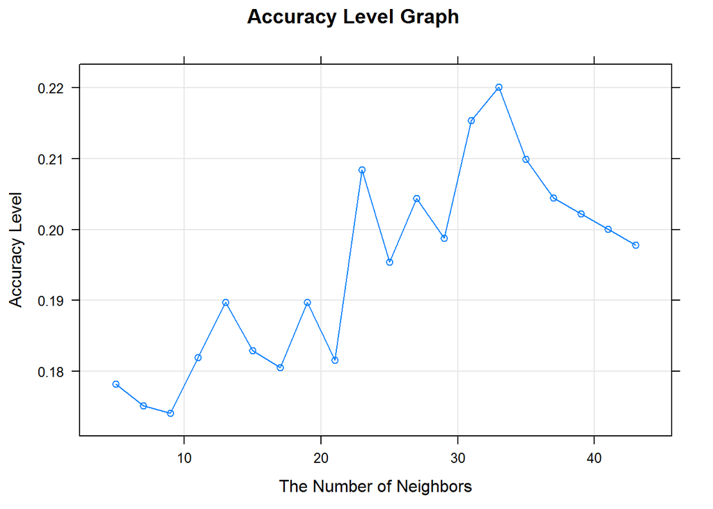

Figure 66: Accuracy Level

From the above graph, you can view the accuracy level changing the number of neighbors, which is actually k value.

**Part c**

```
##                   X             Y             Z Class
##    1:  4.250000e-07  1.649994e-08  3.005000e-07     1
##    2: -2.880001e-07 -1.062000e-06  4.189995e-08     1
##    3: -2.333000e-07  1.029200e-06 -5.599999e-07     1
##    4: -5.287000e-07 -1.646000e-07  3.179998e-07     1
##    5:  7.200002e-08 -1.323200e-06  1.980000e-07     1
##   ---
## 3578: -3.030000e-07 -1.686000e-07  1.143660e-07     8
## 3579: -2.387001e-07  5.389999e-07 -5.899998e-08     8
## 3580: -5.713000e-07 -1.465000e-07  1.890000e-06     8
## 3581:  5.556000e-07 -2.233999e-07  1.859000e-07     8
## 3582:  4.848000e-07  4.911200e-07 -5.670000e-07     8
```

Figure 67: Test data of whole classes

You can see the test data of X,Y,Z axis and the class number from the above graph.

```
##    [1] 2 6 8 7 2 2 7 6 7 7 8 8 2 8 1 5 7 1 7 6 1 6 5 7 1 7 2 1 6 7 7 7 1 2
##   [35] 2 1 7 1 1 8 8 1 2 4 8 6 7 2 6 6 1 8 7 3 2 2 2 1 2 2 5 7 7 8 1 8 8 6
##   [69] 8 6 7 8 2 1 1 2 6 8 7 1 1 6 8 7 7 2 4 8 7 3 1 1 6 8 8 2 7 1 2 2 8 8
##  [103] 1 7 8 1 3 5 8 7 7 2 2 8 2 5 2 2 7 2 2 5 7 2 7 6 4 7 1 8 1 7 7 2 7 7
##  [137] 7 7 2 3 7 8 5 3 2 1 8 6 6 6 7 7 8 7 3 6 2 1 1 1 2 7 7 1 1 2 7 6 7 8
##  [171] 4 8 2 6 6 7 5 7 7 7 4 1 3 6 4 8 2 2 8 1 6 4 3 2 8 6 2 6 8 8 6 6 1 1
##  [205] 2 2 1 2 8 7 8 2 8 1 2 2 5 6 5 6 2 7 6 6 1 2 8 7 2 7 3 2 7 2 2 3 2 2
##  [239] 6 2 8 2 7 7 7 4 4 7 5 5 2 6 3 1 2 7 6 7 3 4 1 2 2 3 7 7 7 2 8 7 2 8
##  [273] 7 2 7 7 7 8 8 2 1 7 7 8 6 7 4 7 8 5 7 4 1 2 8 6 6 6 1 1 6 6 7 1 6 7
##  [307] 6 8 7 3 2 8 1 1 4 4 8 7 1 4 2 1 8 7 2 7 8 1 8 6 3 6 3 1 2 2 7 6 7 8
##  [341] 8 1 3 6 3 2 2 1 2 2 7 6 6 7 2 1 8 4 1 8 6 7 3 2 2 2 7 5 1 2 7 2 2 7
##  [375] 6 5 8 5 1 1 7 2 2 2 2 7 7 2 6 5 1 2 7 1 7 2 7 4 2 8 4 3 2 8 1 6 8 7
##  [409] 1 2 2 1 8 6 7 7 5 1 5 1 1 3 5 7 6 7 8 7 5 1 3 2 5 6 7 7 6 2 2 2 2 2
##  [443] 6 2 7 2 2 7 2 2 2 7 2 2 8 2 7 7 2 8 2 2 2 2 7 6 8 8 8 8 5 7 8 8 2 2
##  [477] 8 2 1 1 8 5 2 2 2 2 2 7 2 7 2 2 6 8 8 6 8 1 7 7 8 7 2 4 2 7 7 7 7 1
```

[output cut: 92 more lines]

Figure 68: Class prediction of test data

You can see the class prediction of test data as a result of creating knn algorithm on the above table.

```
## Confusion Matrix and Statistics
##
##           Reference
## Prediction   1   2   3   4   5   6   7   8
##          1  66  28  55  43  62  58  42  35
##          2  92 190  80  81  84  61 160 154
##          3  22   0  38  28  33  34   3   5
##          4  18   5  38  54  30  29  11  14
##          5  22  12  60  71  55  69  19  13
##          6  56  13  65  52  59  88  23  28
##          7  99 111  76  84  84  73 129 147
##          8  62  93  42  37  26  37  60  64
##
## Overall Statistics
##
##                Accuracy : 0.191
##                  95% CI : (0.1782, 0.2042)
##     No Information Rate : 0.1284
##     P-Value [Acc > NIR] : < 2.2e-16
##
##                   Kappa : 0.0753
##  Mcnemar's Test P-Value : < 2.2e-16
##
## Statistics by Class:
##
##                      Class: 1 Class: 2 Class: 3 Class: 4 Class: 5 Class: 6
## Sensitivity           0.15103  0.42035  0.08370  0.12000  0.12702  0.19599
## Specificity           0.89730  0.77252  0.96004  0.95370  0.91553  0.90552
## Pos Pred Value        0.16967  0.21064  0.23313  0.27136  0.17134  0.22917
## Neg Pred Value        0.88381  0.90224  0.87833  0.88294  0.88408  0.88712
## Prevalence            0.12200  0.12619  0.12674  0.12563  0.12088  0.12535
## Detection Rate        0.01843  0.05304  0.01061  0.01508  0.01535  0.02457
## Detection Prevalence  0.10860  0.25181  0.04551  0.05556  0.08961  0.10720
## Balanced Accuracy     0.52416  0.59644  0.52187  0.53685  0.52127  0.55076
##                      Class: 7 Class: 8
## Sensitivity           0.28859  0.13913
## Specificity           0.78501  0.88565
## Pos Pred Value        0.16065  0.15202
## Neg Pred Value        0.88557  0.87472
## Prevalence            0.12479  0.12842
## Detection Rate        0.03601  0.01787
## Detection Prevalence  0.22418  0.11753
## Balanced Accuracy     0.53680  0.51239
```

Figure 69: Confusion Matrix

After I transformed the class number from numeric to factor, i created confusion matrix. You can see the basic performance evaluation statistics by class above. The class having highest accuracy level is class 2.It refers to whether the data values classified are the correct classification numbers.

**TASK 2**

**Part a**

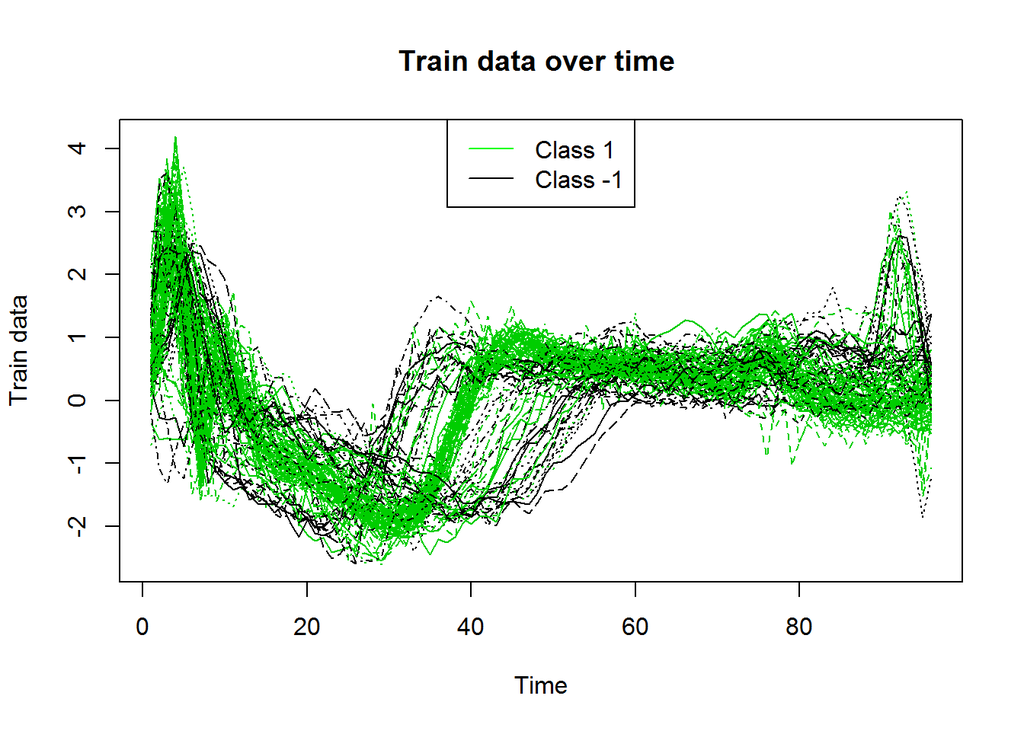

```
## 12345678910
```

```
## $cvl
## [1] -1.138644
##
## $cvls
##  [1] -0.1119513 -0.1119513 -0.1239207 -0.1017334 -0.1377973 -0.1239207
##  [7] -0.1119513 -0.1017334 -0.1119513 -0.1017334
##
## $predictions
##   [1] 0.01871996 0.99197716 0.01805185 0.01742978 0.99197716 0.99184755
##   [7] 0.01871996 0.01943942 0.99184755 0.99184755 0.99210274 0.99184755
##  [13] 0.99184755 0.99197716 0.01805185 0.99184755 0.99184755 0.99197716
##  [19] 0.01805185 0.01943942 0.99184755 0.99171371 0.99171371 0.01805185
##  [25] 0.99171371 0.99171371 0.99171371 0.01871996 0.99171371 0.99184755
##  [31] 0.99171371 0.99171371 0.99184755 0.99184755 0.99197716 0.01742978
##  [37] 0.99171371 0.99171371 0.99184755 0.99171371 0.99197716 0.99171371
```

[output cut: 32 more lines]

Figure 71: Logistic Regression Model on the Training data

I used cvl function since it has already worked cross validation during the process.You can see some data related to cvls,fold, and fullfit. I don’t know why but predict function does not work. I could not add this function to that part but you can see in the code section.

**Part b**

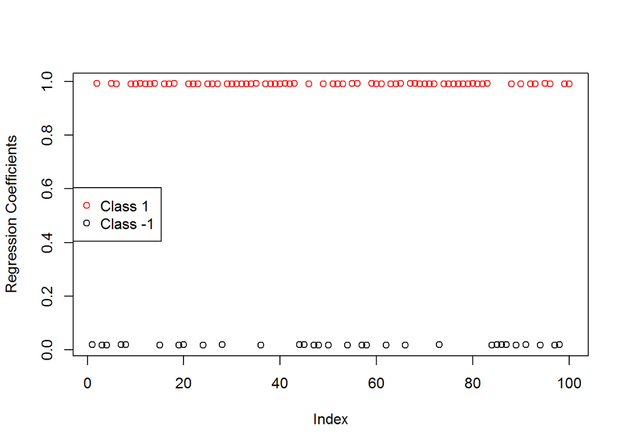

**Part c**

```
## 12345678910
```

```
## $cvl
## [1] -1.148614
##
## $cvls
##  [1] -0.11816645 -0.10299638 -0.12685073 -0.11398946 -0.11398946
##  [6] -0.10299638 -0.09372227 -0.10299638 -0.11398946 -0.15891734
##
## $predictions
##  [1] 0.99184792 0.01871959 0.01871959 0.99157578 0.99184792 0.01805149
##  [7] 0.01943904 0.99171407 0.99184792 0.99222486 0.99197754 0.99157578
## [13] 0.99222486 0.01805149 0.99184792 0.99210274 0.99171407 0.01805149
## [19] 0.01805149 0.99171407 0.99184792 0.99210274 0.01943904 0.99171407
## [25] 0.99184792 0.99171407 0.01805149 0.99197754 0.99197754 0.99184792
## [31] 0.99184792 0.99184792 0.99184792 0.99184792 0.01871959 0.99171407
## [37] 0.99171407 0.99184792 0.99210274 0.99157578 0.99184792 0.99171407
## [43] 0.01871959 0.01943942 0.99157578 0.01943942 0.01871959 0.99171407
## [49] 0.01871959 0.99171407 0.99184792 0.99184792 0.01871959 0.99171407
## [55] 0.99171407 0.02105767 0.01871959 0.99210274 0.99222486 0.99157578
## [61] 0.02105767 0.99171407 0.99171407 0.99184792 0.02105767 0.99171407
## [67] 0.99184792 0.99210274 0.99157578 0.99197754 0.99171407 0.01871959
## [73] 0.99171407 0.99197754 0.99171407 0.99157578 0.99171407 0.99171407
## [79] 0.99197754 0.99184792 0.99171407 0.99171407 0.01943942 0.02105767
## [85] 0.01943904 0.01805149 0.99171407 0.01943942 0.99171407 0.01742943
## [91] 0.99157578 0.99184792 0.01943904 0.99184792 0.99222486 0.02105767
## [97] 0.02105767 0.99157578 0.99184792
##
## $fold
##  1  2  3  4  5  6  7  8  9 10 11 12 13 14 15 16 17 18 19 20 21 22 23 24 25
##  5  5  5  7  9  6  3  6  5 10  3  7 10  8  4  1  6  6  8  8  4  1  3  2  9
## 26 27 28 29 30 31 32 33 34 35 36 37 38 39 40 41 42 43 44 45 46 47 48 49 50
##  6  2  3  3  9  5  9  9  5  4  8  6  4  1  7  9  6  4  1  7  1  9  8  9  2
## 51 52 53 54 55 56 57 58 59 60 61 62 63 64 65 66 67 68 69 70 71 72 73 74 75
##  5  4  5  6  2 10  4  1 10  7 10  6  2  5 10  8  4  1  7  3  2  9  8  3  8
## 76 77 78 79 80 81 82 83 84 85 86 87 88 89 90 91 92 93 94 95 96 97 98 99
##  7  2  8  3  5  2  6  1 10  3  2  8  1  2  7  7  9  3  4 10 10 10  7  4
##
## $fullfit
## Penalized logistic regression object
## 98 regression coefficients of which 2 are non-zero
##
## Loglikelihood =   -1.017293
## L1 penalty =  4.487562   at lambda1 =  1
## L2 penalty =  0.04991764     at lambda2 =  0.002478752
```

Figure 73: Logistic Regression Model on the Time Series Diffrences of Training data

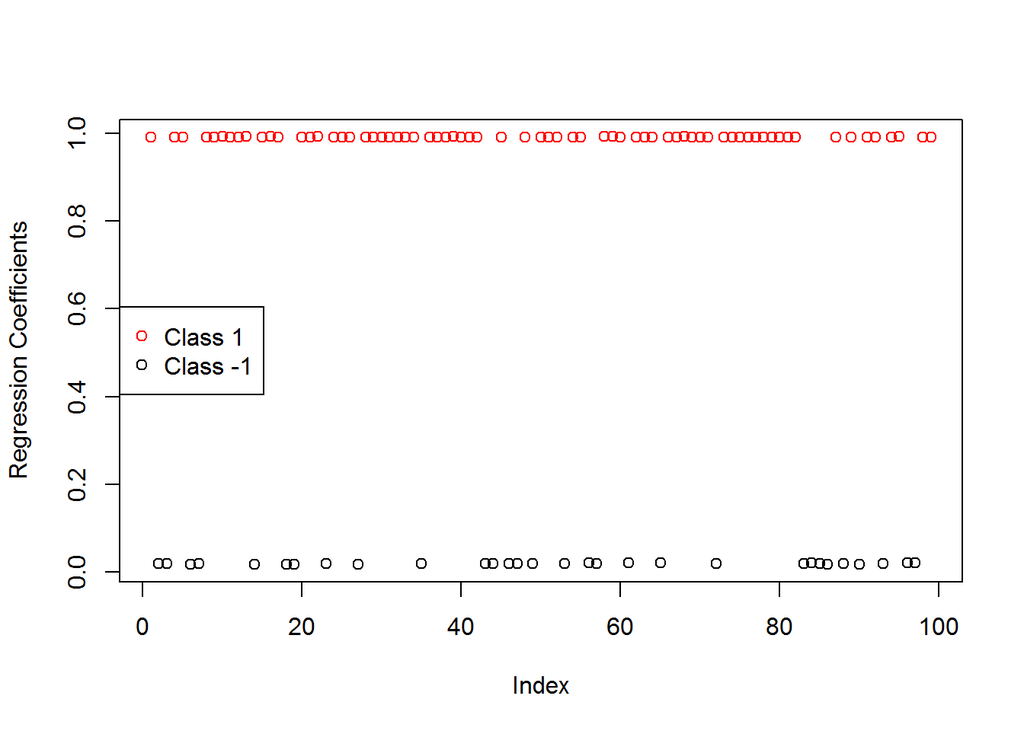

**Part d**

I think there is no such big difference between them. They are nearly the same.

**3.APPENDIX**

**First Task**

**Part a**

require(utils) require(data.table) require(scatterplot3d) require(matrixStats) require(plotly) require(penalized) require(caret) require(ISLR) require(neighbr) require(distances) require(class) require(stats)

xtrainname=‘uWaveGestureLibrary_X_TRAIN’ X_test_data<-as.matrix(read.table(“C:/Users/Merve/Desktop/hmw3/uWaveGestureLibrary_X_TEST”)) X_train_data<-as.matrix(read.table(“C:/Users/Merve/Desktop/hmw3/uWaveGestureLibrary_X_TRAIN”)) Y_train_data<-as.matrix(read.table(“C:/Users/Merve/Desktop/hmw3/uWaveGestureLibrary_Y_TRAIN”)) Y_test_data<-as.matrix(read.table(“C:/Users/Merve/Desktop/hmw3/uWaveGestureLibrary_Y_TEST”)) Z_test_data<-as.matrix(read.table(“C:/Users/Merve/Desktop/hmw3/uWaveGestureLibrary_Z_TEST”)) Z_train_data<-as.matrix(read.table(“C:/Users/Merve/Desktop/hmw3/uWaveGestureLibrary_Z_TRAIN”))

X_train_data_class1<-X_train_data[X_train_data[,1]==1,] #filter all class 1

X_train_data_class1<-X_train_data_class1[1,] #select one instance from class 1 for x axis

matrix(X_train_data_class1) #transform it into matrix form

matrix(X_train_data_class1)[-1,] #delete class information

plot(matrix(X_train_data_class1)[-1,],xlab=“Time”,ylab = “X Train Data”,main = “X Train Data for Class 1 Over Time”) #plot x axis without cumulative sum

Y_train_data_class1<-Y_train_data[X_train_data[,1]==1,] #filter all class 1

Y_train_data_class1<-Y_train_data_class1[1,] #select one instance from class 1 for y axis

plot(matrix(Y_train_data_class1)[-1,],xlab=“Time”,ylab = “Y Train Data”,main = “Y Train Data for Class 1 Over Time”) #plot y axis without cumulative sum

Z_train_data_class1<-Z_train_data[X_train_data[,1]==1,] #filter all class 1

Z_train_data_class1<-Z_train_data_class1[1,] #select one instance from class 1 for z axis

plot(matrix(Z_train_data_class1)[-1,],xlab=“Time”,ylab = “Z Train Data”,main = “Z Train Data for Class 1 Over Time”) #plot z axis without cumulative sum

3 boyutlu çizim için

XYZ_train_data_class1<-cbind(matrix(matrix(X_train_data_class1)[-1,]),matrix(matrix(Y_train_data_class1)[-1,]),matrix(matrix(Z_train_data_class1)[-1,]))

scatterplot3d(XYZ_train_data_class1,xlab = “X axis of train data for class 1”,ylab = “Y axis of train data for class 1”,zlab = “Z axis of train data for class 1”,highlight.3d=TRUE,col.axis=“blue”,col.grid=“lightblue”,pch=20) #Plot for xyz axis without cumulative sum

Her bir axis in kümülatif toplamları, kümülatif formun ayrı ayrı plotları-her axis için- ve toplu 3d scatter plotu df_XYZ_train_data_class1<-data.frame(XYZ_train_data_class1)

df_XYZ_train_data_class1$Cumsum_X1<-cumsum(df_XYZ_train_data_class1$X1) #Cumulative sum of x axis for class 1

df_XYZ_train_data_class1$Cumsum_X2<-cumsum(df_XYZ_train_data_class1$X2) #Cumulative sum of y axis for class 1

df_XYZ_train_data_class1$Cumsum_X3<-cumsum(df_XYZ_train_data_class1$X3) #Cumulative sum of z axis for class 1

df_XYZ_train_data_class1_cbind<-cbind(df_XYZ_train_data_class1$Cumsum_X1,df_XYZ_train_data_class1$Cumsum_X2,df_XYZ_train_data_class1$Cumsum_X3)

colnames(df_XYZ_train_data_class1_cbind)<-c(“X”,“Y”,“Z”)

plot(df_XYZ_train_data_class1$Cumsum_X1,xlab=“Time”,ylab=“X axis data”,main=“Velocity vector of X axis”) #Plot x axis with cumulative sum

plot(df_XYZ_train_data_class1$Cumsum_X2,xlab=“Time”,ylab=“Y axis data”,main=“Velocity vector of Y axis”) #Plot y axis with cumulative sum

plot(df_XYZ_train_data_class1$Cumsum_X3,xlab=“Time”,ylab=“Z axis data”,main=“Velocity vector of Z axis”) #Plot z axis with cumulative sum

scatterplot3d(df_XYZ_train_data_class1$Cumsum_X1,df_XYZ_train_data_class1$Cumsum_X2,df_XYZ_train_data_class1$Cumsum_X3,xlab=“Cumulative Sum of X axis for Training Data Class 1”,ylab=“Cumulative Sum of Y axis for Training Data Class 1”,zlab=“Cumulative Sum of Z axis for Training Data Class 1”)

**Part b**

X_test_data_class1<-X_test_data[X_test_data[,1]==1,] #filter all class 1

X_test_data_class1<-X_test_data_class1[,-1]

X_test_data_class1_rowcumsum<-rowCumsums(X_test_data_class1) #sum of rows for x axis of class 1

X_test_data_class1_rowcumsum_lastpoint<-X_test_data_class1_rowcumsum[,315]

X_test_data_class1_rowcumsum_lastpoint_matrix<-matrix(X_test_data_class1_rowcumsum_lastpoint)

Y_test_data_class1<-Y_test_data[Y_test_data[,1]==1,] #filter all class 1

Y_test_data_class1<-Y_test_data_class1[,-1]

Y_test_data_class1_rowcumsum<-rowCumsums(Y_test_data_class1) #sum of rows for y axis of class 1

Y_test_data_class1_rowcumsum_lastpoint<-Y_test_data_class1_rowcumsum[,315]

Y_test_data_class1_rowcumsum_lastpoint_matrix<-matrix(Y_test_data_class1_rowcumsum_lastpoint)

Z_test_data_class1<-Z_test_data[Z_test_data[,1]==1,] #filter all class 1

Z_test_data_class1<-Z_test_data_class1[,-1]

Z_test_data_class1_rowcumsum<-rowCumsums(Z_test_data_class1) #sum of rows for z axis of class 1

Z_test_data_class1_rowcumsum_lastpoint<-Z_test_data_class1_rowcumsum[,315]

Z_test_data_class1_rowcumsum_lastpoint_matrix<-matrix(Z_test_data_class1_rowcumsum_lastpoint)

XYZ_test_data_class1_rowcumsum_lastpoint_matrix<-cbind(X_test_data_class1_rowcumsum_lastpoint_matrix,Y_test_data_class1_rowcumsum_lastpoint_matrix,Z_test_data_class1_rowcumsum_lastpoint_matrix) #combine xyz for class 1

colnames(XYZ_test_data_class1_rowcumsum_lastpoint_matrix)<- c(“X”,“Y”,“Z”)

XYZ_test_data_class1_rowcumsum_lastpoint_matrix

set.seed(1234)

for (i in 1:(nrow(XYZ_test_data_class1_rowcumsum_lastpoint_matrix))) { combined_class1<-rbind(XYZ_test_data_class1_rowcumsum_lastpoint_matrix[i,],df_XYZ_train_data_class1_cbind)

combined_class1_euclidean<-distances(combined_class1)

combined_class1_manhattan<-dist(combined_class1,method=“manhattan”)

}

combined_class1_euclidean combined_class1_manhattan

X_train_data_class1<-X_train_data[X_train_data[,1]==1,] #filter all class 1

X_train_data_class1<-X_train_data_class1[,-1]

X_train_data_class1_rowcumsum<-rowCumsums(X_train_data_class1) #sum of rows for x axis of class 1

X_train_data_class1_rowcumsum_lastpoint<-X_train_data_class1_rowcumsum[,315]

X_train_data_class1_rowcumsum_lastpoint_matrix<-matrix(X_train_data_class1_rowcumsum_lastpoint)

Y_train_data_class1<-Y_train_data[X_train_data[,1]==1,] #filter all class 1

Y_train_data_class1<-Y_train_data_class1[,-1]

Y_train_data_class1_rowcumsum<-rowCumsums(Y_train_data_class1) #sum of rows for y axis of class 1

Y_train_data_class1_rowcumsum_lastpoint<-Y_train_data_class1_rowcumsum[,315]

Y_train_data_class1_rowcumsum_lastpoint_matrix<-matrix(Y_train_data_class1_rowcumsum_lastpoint)

Z_train_data_class1<-Z_train_data[X_train_data[,1]==1,] #filter all class 1

Z_train_data_class1<-Z_train_data_class1[,-1]

Z_train_data_class1_rowcumsum<-rowCumsums(Z_train_data_class1) #sum of rows for x axis of class 1

Z_train_data_class1_rowcumsum_lastpoint<-Z_train_data_class1_rowcumsum[,315]

Z_train_data_class1_rowcumsum_lastpoint_matrix<-matrix(Z_train_data_class1_rowcumsum_lastpoint)

XYZ_train_class1_merge<-data.table(cbind(X_train_data_class1_rowcumsum_lastpoint_matrix,Y_train_data_class1_rowcumsum_lastpoint_matrix,Z_train_data_class1_rowcumsum_lastpoint_matrix))

colnames(XYZ_train_class1_merge)<-c(“X”,“Y”,“Z”)

XYZ_train_class1_merge

XYZ_train_class1_merge<-XYZ_train_class1_merge[,Class:=“1”]

XYZ_train<-rbind(XYZ_train_class1_merge,XYZ_train_class2_merge,XYZ_train_class3_merge,XYZ_train_class4_merge,XYZ_train_class5_merge,XYZ_train_class6_merge,XYZ_train_class7_merge,XYZ_train_class8_merge)

table(XYZ_train$Class)

set.seed(1234)

trcontrol<-trainControl(method=“repeatedcv”,number = 10)

knnFit <- train(Class ~ ., data = XYZ_train, method = “knn”, trControl = trcontrol, preProcess = c(“scale”), tuneLength = 20)

knnFit

plot(knnFit,xlab=“The Number of Neighbors”, ylab=“Accuracy Level”, main=“Accuracy Level Graph”)

**Part c**

XYZ_test_class1_merge<-data.table(cbind(X_test_data_class1_rowcumsum_lastpoint_matrix,Y_test_data_class1_rowcumsum_lastpoint_matrix,Z_test_data_class1_rowcumsum_lastpoint_matrix))

colnames(XYZ_test_class1_merge)<-c(“X”,“Y”,“Z”)

XYZ_test_class1_merge<-XYZ_test_class1_merge[,Class:=“1”]

XYZ_test_class2_merge<-data.table(cbind(X_test_data_class2_rowcumsum_lastpoint_matrix,Y_test_data_class2_rowcumsum_lastpoint_matrix,Z_test_data_class2_rowcumsum_lastpoint_matrix))

colnames(XYZ_test_class2_merge)<-c(“X”,“Y”,“Z”)

XYZ_test_class2_merge<-XYZ_test_class2_merge[,Class:=“2”]

XYZ_test_class3_merge<-data.table(cbind(X_test_data_class3_rowcumsum_lastpoint_matrix,Y_test_data_class3_rowcumsum_lastpoint_matrix,Z_test_data_class3_rowcumsum_lastpoint_matrix))

colnames(XYZ_test_class3_merge)<-c(“X”,“Y”,“Z”)

XYZ_test_class3_merge<-XYZ_test_class3_merge[,Class:=“3”]

XYZ_test_class4_merge<-data.table(cbind(X_test_data_class4_rowcumsum_lastpoint_matrix,Y_test_data_class4_rowcumsum_lastpoint_matrix,Z_test_data_class4_rowcumsum_lastpoint_matrix))

colnames(XYZ_test_class4_merge)<-c(“X”,“Y”,“Z”)

XYZ_test_class4_merge<-XYZ_test_class4_merge[,Class:=“4”]

XYZ_test_class5_merge<-data.table(cbind(X_test_data_class5_rowcumsum_lastpoint_matrix,Y_test_data_class5_rowcumsum_lastpoint_matrix,Z_test_data_class5_rowcumsum_lastpoint_matrix))

colnames(XYZ_test_class5_merge)<-c(“X”,“Y”,“Z”)

XYZ_test_class5_merge<-XYZ_test_class5_merge[,Class:=“5”]

XYZ_test_class6_merge<-data.table(cbind(X_test_data_class6_rowcumsum_lastpoint_matrix,Y_test_data_class6_rowcumsum_lastpoint_matrix,Z_test_data_class6_rowcumsum_lastpoint_matrix))

colnames(XYZ_test_class6_merge)<-c(“X”,“Y”,“Z”)

XYZ_test_class6_merge<-XYZ_test_class6_merge[,Class:=“6”]

XYZ_test_class7_merge<-data.table(cbind(X_test_data_class7_rowcumsum_lastpoint_matrix,Y_test_data_class7_rowcumsum_lastpoint_matrix,Z_test_data_class7_rowcumsum_lastpoint_matrix))

colnames(XYZ_test_class7_merge)<-c(“X”,“Y”,“Z”)

XYZ_test_class7_merge<-XYZ_test_class7_merge[,Class:=“7”]

XYZ_test_class8_merge<-data.table(cbind(X_test_data_class8_rowcumsum_lastpoint_matrix,Y_test_data_class8_rowcumsum_lastpoint_matrix,Z_test_data_class8_rowcumsum_lastpoint_matrix))

colnames(XYZ_test_class8_merge)<-c(“X”,“Y”,“Z”)

XYZ_test_class8_merge<-XYZ_test_class8_merge[,Class:=“8”]

XYZ_test<-rbind (XYZ_test_class1_merge,XYZ_test_class2_merge,XYZ_test_class3_merge,XYZ_test_class4_merge,XYZ_test_class5_merge,XYZ_test_class6_merge,XYZ_test_class7_merge,XYZ_test_class8_merge)

XYZ_test

knnPredict <- predict(knnFit,newdata = XYZ_test )

knnPredict

XYZ_test$Class<-as.factor(XYZ_test$Class)

confusionMatrix(knnPredict, XYZ_test$Class )

**Second Task**

**Part a**

require(penalized)

set.seed(455)

traindata<-as.matrix(read.table(“C:/Users/Merve/Desktop/2018-2019 1.dönem/IE582/4.WEEK/NN_Classification/ecgTRAIN”))

trainclass=traindata[,1]

traindata_withoutclass=traindata[,2:ncol(traindata)]

tlength_train=ncol(traindata_withoutclass)

noftimeseries_train=nrow(traindata_withoutclass)

testdata<-as.matrix(read.table(“C:/Users/Merve/Desktop/2018-2019 1.dönem/IE582/4.WEEK/NN_Classification/ecgTEST”))

matplot(t(traindata_withoutclass),type=“l”,col=trainclass+10,xlab=“Time”,ylab=“Train data”, main=“Train data over time”)

legend(“top”, legend=c(“Class 1”, “Class -1”),col=c(“green”, “black”),lwd=1)

trainclass<-as.factor(trainclass)

lambda2<-exp (seq (-6, 1, length = 1))

lambda1<-1

cvFused<-cvl(trainclass,lambda1=lambda1,lambda2=lambda2,traindata, model=c(“logistic”),fold=10)

cvFused

cvFused_test<-predict(cvFused,data = testdata )

**Part b**

cvFused_predictions<-cvFused$predictions

plot(cvFused_predictions, col=trainclass,ylab=“Regression Coefficients”)

legend(“left”, legend=c(“Class 1”, “Class -1”),col=c(“red”, “black”),pch=1)

**Part c**

traindata[,2:ncol(traindata)]

diff_traindata<-diff(traindata[,2:ncol(traindata)])

trainclass<-traindata[,1]

combined<-cbind(trainclass[-1],diff_traindata)

combined

lambda2<-exp (seq (-6, 1, length = 1))

lambda1<-1

trainclass<-as.factor(trainclass)

cvFused_new<-cvl(trainclass[-1],lambda1=lambda1,lambda2=lambda2,combined, model=c(“logistic”),fold=10)

cvFused_new

cvFused_test_new<-predict(cvFused_new,data = testdata )

cvFused_new_predictions<-cvFused_new$predictions

plot(cvFused_new_predictions, col=trainclass[-1],ylab=“Regression Coefficients”)

legend(“left”, legend=c(“Class 1”, “Class -1”),col=c(“red”, “black”),pch=1)